# 3D GM and Phylogenetic Principal Components Analysis (PPCA)

Angie Pena  
12-5-16

### Research Question and Background

[figure not shown]

- Variation in hamate morphology can affect mobility in the wrist
- paleoanthropologists will use it as a proxy for locomotor repertoire in fossils

*How does hamate morphology vary among extant primate groups with unique locomotor repertoires?*

*How much of the variation in hamate morphology in extant primates can be attributed to locomotor style rather than phylogeny?*

### Almecija et al. 2015

[figure not shown]

### What types of analyses can we use to answer these questions?

**phylogenetic principal components analysis (PPCA)**(Revell, 2009)

- removes variation due to phylogeny
- People will often use traditional PCA without accounting for the non-independence among species (Revell, 2009)
- much of the variation in hamate structure may be due to taxon-related differences which need to be taken into account

I will also be using **MANOVA** on the PPC data to test the relationship of shape variation as a function of locomotor repertoire.

### Packages needed for these analyses

```r
library(dplyr)
```

PPCA analysis

```r
library(geomorph)
```

MANOVA

```r
library(heplots)
```

Plotting phylogenetic tree

```r
library(phytools)
```

### Data

- **3D landmark data** on the hamates of a variety of primates with different locomotor repertoires. This is a data set of 3D hamate landmarks from a variety of extant primate species (courtesy of Almecija et al. 2015).
- **locomotor repertoires** of these primates
- **phylogenetic tree** data on the taxa sampled in this study. I obtained my phylogenetic data from the website, [10ktrees](http://10ktrees.fas.harvard.edu/downloadTrees.html).

*DISCLAIMER: The 3D landmark data was used for this project with permission from Dr. Sergio Almecija. DO NOT use this data set for other products without asking Sergio first!*

### Let's load it all in...

3D Landmarks with species and locomotor info

```r
hamates <- read.table("C:/Angie/CASHP/Classes/Fall 2016/Stats/Project/hamateprimatedata.txt", sep = "\t", header = TRUE)
```

Tree Data

```r
mytree <- read.nexus("C:/Angie/CASHP/Classes/Fall 2016/Stats/Project/primatestree.nex")
```

3D Mesh of Hamate

```r
mesh <- read.ply("C:/Angie/CASHP/Classes/Fall 2016/Stats/Project/ppaniscushammesh.ply")
```

[figure not shown]

### Data Manipulation

```r
hamates3d <- arrayspecs((data.frame(hamates[,-c(1:3)], row.names = hamates[,1])), 63, 3)

GPA <- gpagen(hamates3d)
```

Right now the data is in a 3D array. `phyl.pca()` requires species means in a 2D matrix form. We also need need to add the species and locomotion columns back into the matrix so that we can group by species to find the species means.

```r
proc2D <- as.data.frame(two.d.array(GPA$coords))
proc2D$species <- hamates$Species
proc2D$locomotion <- hamates$Locomotion
```

### Species Means

Group by species and locomotion, and calculate mean

```r
specmeans <- as.data.frame(dplyr::summarise_each(dplyr::group_by(proc2D, species, locomotion), dplyr::funs(mean)))
```

`phyl.pca()` can only use numeric data, so let's remove species and locomotor info and add in the species names as row names such that PPCA can match up this data with the phylogenetic data.

```r
final <- data.frame(specmeans[,-c(1,2)], row.names = specmeans[,1])
```

The 2D array is fine for the PPCA analysis, but for some of the other functions in `geomorph`, this data needs to be in 3D array format.

```r
specmeans3d <- arrayspecs(final, 63, 3)
```

### geomorph::phyl.pca

```r
PPCA <- phyl.pca(tree = mytree, Y = final, method="BM", mode="cov")
```

That's it…lol

### geomorph::phylomorphospace

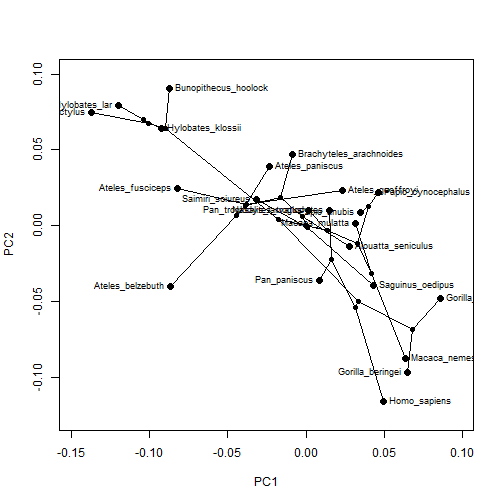

```r
phyloplot <- phylomorphospace(mytree, PPCA$S[,c(1,2)], A = NULL, label = "horizontal", method = c("dynamic"))
```

### Steps for plotting the 3D hamate morphs

*1. Calculate the mean shape of all the GPA coordinates*

```r
mshape <- mshape(GPA$coords)
```

*2. Find the individual in the dataset that is closest to the mean shape*

```r
meanspec <- findMeanSpec(GPA$coords)
```

*3. Warp the mesh of this individual to match the coordinates of the mean shape*

```r
refmesh <- warpRefMesh(mesh, mesh.coord = GPA$coords[,,meanspec], ref = mshape, color = "grey")
```

*4. Extract PPCA coordinates and eigenvectors from first 2 PPCs*

```r
PPCAcoords <- as.data.frame(PPCA$S)
PPCAevec <- as.data.frame(PPCA$Evec)
ppcavec1 <- aperm(`dim<-`(t(PPCAevec$PC1), list(3, 63)), c(2, 1))
ppcavec2 <- aperm(`dim<-`(t(PPCAevec$PC2), list(3, 63)), c(2, 1))
```

*5. Find the min/max coords for your PPCs*

min/max for PPC1

```r
PPC1min <- min(PPCAcoords$PC1)

PPC1max <- max(PPCAcoords$PC1)
```

min/max for PPC2

```r
PPC2min <- min(PPCAcoords$PC2)

PPC2max <- max(PPCAcoords$PC2)
```

*6. Scale eigenvalues and add mean shape*

PPC1 min

```r
Evec1min <- (ppcavec1 * PPC1min) + mshape
```

PPC1 max

```r
Evec1max <- (ppcavec1 * PPC1max) + mshape
```

PPC2 min

```r
Evec2min <- (ppcavec2 * PPC2min) + mshape
```

PPC2 max

```r
Evec2max <- (ppcavec2 * PPC2max) + mshape
```

*7. Use `plotRefToTarget` to morph this new mesh to the PC extremes.*

PPC1 min

```r
plotRefToTarget(mshape, Evec1min, mesh = refmesh, method= "surface")
```

PPC1 max

```r
plotRefToTarget(mshape, Evec1max, mesh = refmesh, method= "surface")
```

PPC2 min

```r
plotRefToTarget(mshape, Evec2min, mesh = refmesh, method= "surface")
```

PPC2 max

```r
plotRefToTarget(mshape, Evec2max, mesh = refmesh, method= "surface")
```

PPC1 minimum

[figure not shown]

PPC1 maximum

[figure not shown]

PPC2 minimum

[figure not shown]

PPC2 maximum

[figure not shown]

### Continuous Trait Phylogenetic Map

*Another way to visualize your PPCs. Make a pretty plot of a continuous variable (such as the PPC loadings) on a phylogenetic tree.*

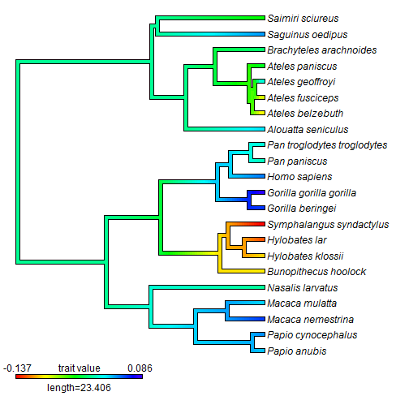

We can do this using the `contMap()` function in `phytools`

`contMap(tree, x, type="phylogram", plot=TRUE)`

`tree` - object of class “`phylo`”.

`x` - vector of phenotypic trait values for species.

`type` - type of plot desired. Options are “`phylogram`” for a rightward square phylogram; and “`fan`” for a circular phylogram.

`plot` - logical value indicating whether or not to plot the tree. If `plot=FALSE` then an object of class “`contMap`” will be returned without plotting.

```r
contMap(mytree, PPCA$S[,1], type = "phylogram", plot = TRUE)
```

### PPC1

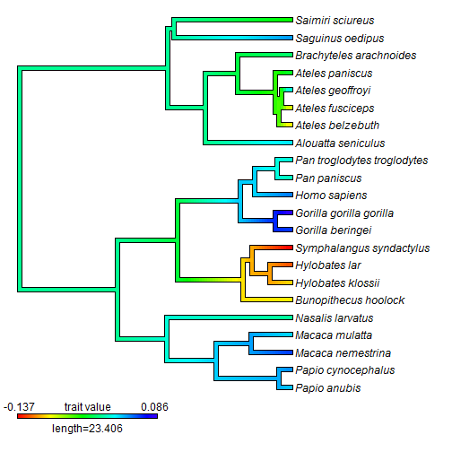

### We can also take a look at PPC2...

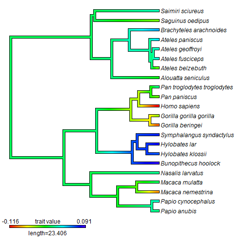

### MANOVA

Alright cool. So, what effect does locomotion have?

```r
manova <- manova(as.matrix(PPCA$S[,c(1,2,3,4,5)]) ~ specmeans$locomotion)
summary(manova)
```

```
                     Df Pillai approx F num Df den Df    Pr(>F)
specmeans$locomotion  4 1.9855   3.1539     20     64 0.0002555 ***
Residuals            17
---
Signif. codes:  0 '***' 0.001 '**' 0.01 '*' 0.05 '.' 0.1 ' ' 1
```

```r
etasq(manova)
```

```
                         eta^2
specmeans$locomotion 0.4963698
```

`etasq()` calculates the amount of variance in a sample due to a given factor. Based on our eta squared results, about **50%** of the variance in our first five PPCs is attributable to locomotion.

### Data Interpretation

- While regular PCA displayed clear separation among phylogenetic groups, the PPCA showed that some atelids appeared to converge with hylobatids on PC1 … Why?
- Homs converge with OWM
- According to our MANOVA results, **50%** of the variation in our first five PPCs is attributable to locomotion.

[figure not shown]

### References

Almecija, S., Orr, C.M., Tocheri, M.W., Patel, B.A., Jungers, W.L., 2015. Exploring Phylogenetic and Functional Signals in Complex Morphologies: The Hamate of Extant Anthropoids as a Test-Case Study. Anatomical Record. 298, 212-229.

Arnold, C., Matthews L.J., and Nunn C.L., 2010. The 10kTrees Website: A New Online Resource for Primate Phylogeny. Evolutionary Anthropology. 19, 114-118.

Revell, L.J., 2009. Size-Correction and Principal Components for Interspecific Comparative Studies. Evolution. 63, 3258-3268.